# Tutorial_7_own_solutions_markdown

Manuel Schreiber

**Tutorial 7 Business Analytics - own solutions**

R Markdown - The definitive guide (online book): https://bookdown.org/yihui/rmarkdown/ Tidymodels Documentation: https://tidymodels.org

```r
#install.packages("tidymodels")

## checking for updates of the tidyverse package
#tidyverse_update()

#install.packages("GGally")
```

### Loading Packages

```r
library(tidyverse) # collection of packages for data analysis including: ggplot2 (data visualization package), dplyr (data manipulation package), tidyr, readr (faster read.csv() functions that create tibble objects instead of data.frames), purrr, tibble (wrapper around data.frames for better printing), stringr, forcats

library(lubridate) # tools to parse and manipuulate dates

library(GGally) # ggplot2 extension (for a heat map plot)

library(graphics) # base graphics (e.g. histogram)

library(stats) # computing distribution functions, distribution quantiles; random number generation

library(car) # companion to applied regression package

library(lmtest) # testing linear regression models package

library(aod) # analysis of overdispersed data package

library(tidymodels) # collection of packages for modeling and machine learning
```

```r
# getting the current WD
getwd()
```

```
[1] "/Users/Manu/Desktop/TUM_Master_Mgt_Technology/TUM_WS_20/Business Analytics/Tutorials/Tutorial 7 Data Preparation"
```

```r
# changing the WD
##setwd("/Users/Manu/Desktop/TUM Master Mgt & Technology/TUM WS 20/Business Analytics/Tutorials/Tutorial 7 Data Preparation")
```

*Controlling the size of plots/images*

```r
# The Markdown syntax is: ![caption](path/to/image)
```

The size of plots made in R can be controlled by the chunk option **fig.width** and **fig.height** (in inches). Equivalently, you can use the **fig.dim** option to specify the width and height in a numeric vector of length 2, e.g., fig.dim = c(8, 6) means fig.width = 8 and fig.height = 6. These options set the physical size of plots, and you can choose to display a different size in the output using chunk options **out.width** and **out.height**, e.g., out.width = “50%”.

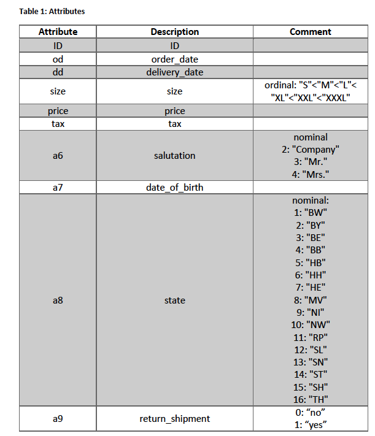

Attributes table

## *Exercise 7.1*

The data set (raw_data.csv) contains data from an online shop. Table 1 describes the attributes and values.

### a) Load raw_data.csv and rename all attributes to match the “description” column in Table 1. Hint: read_delim(), rename()

```r
# read_delim() is amore general version of read_csv
raw_data <- read_delim("raw_data.csv",delim = ";")
head(raw_data)
```

| ID | od | dd | size | price | tax | a6 | a7 | a8 | a9 |
| --- | --- | --- | --- | --- | --- | --- | --- | --- | --- |
| 103939 | 2012-06-26 | ? | l | 29.9 | 5.68 | 4 | 1900-11-19 | 8 | 0 |
| 11788 | 2012-04-10 | 2012-04-11 | l | 49.9 | 9.48 | 4 | 1953-05-24 | 7 | 1 |
| 96553 | 2012-06-20 | 2012-06-21 | m | 59.9 | 11.38 | 4 | 1954-04-10 | 11 | 0 |
| 100950 | 2012-06-24 | 2012-06-26 | l | 69.9 | 13.28 | 4 | 1965-01-11 | 7 | 0 |
| 223454 | 2012-09-22 | 1990-12-31 | xxl | 89.9 | 17.08 | 4 | 1962-05-11 | 10 | 0 |
| 63989 | 2012-05-22 | 2012-05-23 | xxl | 39.9 | 7.58 | 4 | 1955-05-23 | 15 | 1 |

```r
# getting all the feature names
names(raw_data)
```

```
 [1] "ID"    "od"    "dd"    "size"  "price" "tax"   "a6"    "a7"    "a8"
[10] "a9"
```

```r
# renaming the column names:

colnames(raw_data) <-  c("ID","order_date","delivery_date", "size", "price","tax","salutation","date_of_birth","state","return_shipment")

names(raw_data)
```

```
 [1] "ID"              "order_date"      "delivery_date"   "size"
 [5] "price"           "tax"             "salutation"      "date_of_birth"
 [9] "state"           "return_shipment"
```

### b) Correct the data types for all nominal attributes and assign the corresponding labels from the “comment” column in Table 1. Hint: mutate(), factor()

```r
# inspecting dimensionality, features names, data types and the first few values
str(raw_data)
```

```
tibble [300 × 10] (S3: spec_tbl_df/tbl_df/tbl/data.frame)
 $ ID             : num [1:300] 103939 11788 96553 100950 223454 ...
 $ order_date     : Date[1:300], format: "2012-06-26" "2012-04-10" ...
 $ delivery_date  : chr [1:300] "?" "2012-04-11" "2012-06-21" "2012-06-26" ...
 $ size           : chr [1:300] "l" "l" "m" "l" ...
 $ price          : num [1:300] 29.9 49.9 59.9 69.9 89.9 39.9 39.9 59.9 69.9 39.9 ...
 $ tax            : num [1:300] 5.68 9.48 11.38 13.28 17.08 ...
 $ salutation     : num [1:300] 4 4 4 4 4 4 4 2 4 4 ...
 $ date_of_birth  : chr [1:300] "1900-11-19" "1953-05-24" "1954-04-10" "1965-01-11" ...
 $ state          : num [1:300] 8 7 11 7 10 15 10 1 1 11 ...
 $ return_shipment: num [1:300] 0 1 0 0 0 1 1 0 1 0 ...
 - attr(*, "spec")=
  .. cols(
  ..   ID = col_double(),
  ..   od = col_date(format = ""),
  ..   dd = col_character(),
  ..   size = col_character(),
  ..   price = col_double(),
  ..   tax = col_double(),
  ..   a6 = col_double(),
  ..   a7 = col_character(),
  ..   a8 = col_double(),
  ..   a9 = col_double()
  .. )
```

The attributes/features “salutation”, “state” and “return_shipment” are nominal attributes (simple distinction and no order).

```r
# getting the different values of the salutation attribute
unique(raw_data$salutation);
```

```
[1] 4 2 3
```

```r
unique(raw_data$state);
```

```
 [1]  8  7 11 10 15  1  3  2  6 13  5 12  9 14  4 16
```

```r
unique(raw_data$return_shipment)
```

```
[1] 0 1
```

**Nominal attributes:** Values of Nominal attributes represent some category or state (simple distinction) and that’s why nominal attributes also referred as categorical attributes and there is no order (rank, position) among values of a nominal attribute. Example : Binary Attributes : Binary data have only 2 values/states.

```r
# summary stats for all attributes
summary(raw_data)
```

```
       ID           order_date         delivery_date          size
 Min.   :  2292   Min.   :2012-04-02   Length:300         Length:300
 1st Qu.:108790   1st Qu.:2012-06-27   Class :character   Class :character
 Median :252054   Median :2012-10-16   Mode  :character   Mode  :character
 Mean   :247748   Mean   :2012-10-17
 3rd Qu.:379603   3rd Qu.:2013-02-06
 Max.   :480356   Max.   :2013-03-31

     price             tax          salutation   date_of_birth
 Min.   :  9.90   Min.   : 1.88   Min.   :2.00   Length:300
 1st Qu.: 29.90   1st Qu.: 5.68   1st Qu.:4.00   Class :character
 Median : 49.90   Median : 9.48   Median :4.00   Mode  :character
 Mean   : 56.33   Mean   :10.70   Mean   :3.98
 3rd Qu.: 69.90   3rd Qu.:13.28   3rd Qu.:4.00
 Max.   :359.00   Max.   :68.21   Max.   :4.00
 NA's   :6        NA's   :6
     state       return_shipment
 Min.   : 1.00   Min.   :0.0000
 1st Qu.: 2.00   1st Qu.:0.0000
 Median : 8.00   Median :0.0000
 Mean   : 7.22   Mean   :0.4567
 3rd Qu.:10.00   3rd Qu.:1.0000
 Max.   :16.00   Max.   :1.0000
```

```r
# the mutate() function creates, modifies or deletes columns

# transforming the salutation variable so that we have 3 different classes/categories using the factor function

# levels are the catagory/class values that the data vector takes on now, labels contains the new labels
raw_data <- mutate(raw_data, salutation = factor(raw_data$salutation, levels =c(2,3,4), labels = c("Company", "Mr.", "Mrs.")))



head(raw_data$salutation)
```

```
[1] Mrs. Mrs. Mrs. Mrs. Mrs. Mrs.
Levels: Company Mr. Mrs.
```

```r
# transforming the other two nominal attributes:
raw_data <- mutate(raw_data, return_shipment = factor(raw_data$return_shipment, levels =c(0,1), labels = c("No", "Yes")))

head(raw_data$return_shipment);
```

```
[1] No  Yes No  No  No  Yes
Levels: No Yes
```

```r
raw_data <- mutate(raw_data, state = factor(raw_data$state, labels = c("BW", "BY", "BE", "BB", "HB", "HH", "HE", "MV", "NI", "NW", "RP", "SL", "SN", "ST", "SH", "TH")))

head(raw_data$state)
```

```
[1] MV HE RP HE NW SH
Levels: BW BY BE BB HB HH HE MV NI NW RP SL SN ST SH TH
```

```r
summary(raw_data);
```

```
       ID           order_date         delivery_date          size
 Min.   :  2292   Min.   :2012-04-02   Length:300         Length:300
 1st Qu.:108790   1st Qu.:2012-06-27   Class :character   Class :character
 Median :252054   Median :2012-10-16   Mode  :character   Mode  :character
 Mean   :247748   Mean   :2012-10-17
 3rd Qu.:379603   3rd Qu.:2013-02-06
 Max.   :480356   Max.   :2013-03-31

     price             tax          salutation  date_of_birth          state
 Min.   :  9.90   Min.   : 1.88   Company:  1   Length:300         NW     :83
 1st Qu.: 29.90   1st Qu.: 5.68   Mr.    :  4   Class :character   BW     :40
 Median : 49.90   Median : 9.48   Mrs.   :295   Mode  :character   BY     :38
 Mean   : 56.33   Mean   :10.70                                    MV     :30
 3rd Qu.: 69.90   3rd Qu.:13.28                                    RP     :22
 Max.   :359.00   Max.   :68.21                                    HE     :20
 NA's   :6        NA's   :6                                        (Other):67
 return_shipment
 No :163
 Yes:137
```

```r
head(raw_data)
```

| ID | order_date | delivery_date | size | price | tax | salutation | date_of_birth | state | return_shipment |
| --- | --- | --- | --- | --- | --- | --- | --- | --- | --- |
| 103939 | 2012-06-26 | ? | l | 29.9 | 5.68 | Mrs. | 1900-11-19 | MV | No |
| 11788 | 2012-04-10 | 2012-04-11 | l | 49.9 | 9.48 | Mrs. | 1953-05-24 | HE | Yes |
| 96553 | 2012-06-20 | 2012-06-21 | m | 59.9 | 11.38 | Mrs. | 1954-04-10 | RP | No |
| 100950 | 2012-06-24 | 2012-06-26 | l | 69.9 | 13.28 | Mrs. | 1965-01-11 | HE | No |
| 223454 | 2012-09-22 | 1990-12-31 | xxl | 89.9 | 17.08 | Mrs. | 1962-05-11 | NW | No |
| 63989 | 2012-05-22 | 2012-05-23 | xxl | 39.9 | 7.58 | Mrs. | 1955-05-23 | SH | Yes |